# EP1162_Prelim_Data_Screening

Hardy Griesbauer

18/02/2020

```r
knitr::opts_chunk$set(message=FALSE, warning = FALSE)
library(tidyverse)

# Load data
load("../data/ep1162_Data.RData")
```

## Preliminary screening

I did some preliminary screening, to confirm data entry and detect any potential outliers. Some findings below.

## Outliers

Quick boxplot to confirm DBH and height measurements

#### DBH

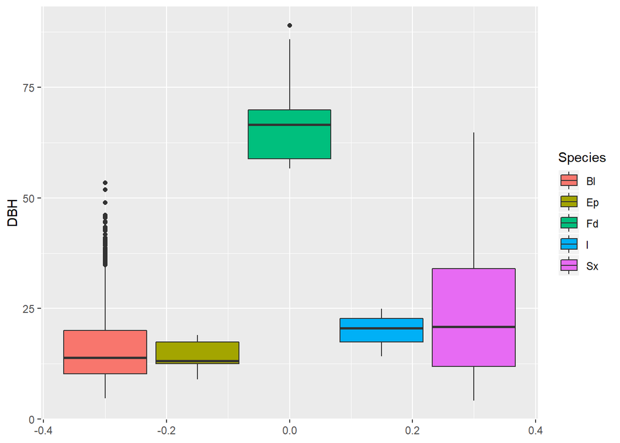

DBH measurements look reasonable, and no major outliers. Note that there is a tree with species recorded as “l”.

#### Height

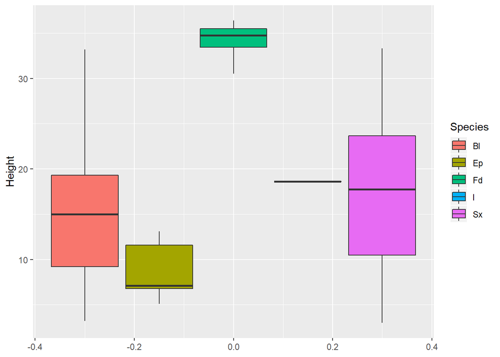

Again, measurements look reasonable here.

### Data entry

One tree has species recorded as “l”. I assume that it’s SAF, but might be worthwhile to verify with the field cards?

| Plot | TreeID | Species | Sector | Year | Status | DBH | Height | Comments | Conk | BlindConk | Scar | Fork.Crook | Frost.Crack | Mistletoe | R.Branch | DBT | Crown.Class | L.Crown |
| --- | --- | --- | --- | --- | --- | --- | --- | --- | --- | --- | --- | --- | --- | --- | --- | --- | --- | --- |
| 16 | 314 | l | 2 | 1992 | Live | 14.2 | NA | NA | NA | NA | NA | NA | NA | NA | NA | NA | NA | NA |
| 16 | 314 | l | 2 | 1994 | Live | NA | NA | NA | NA | NA | NA | NA | NA | NA | NA | NA | NA | NA |
| 16 | 314 | l | 2 | 1997 | Live | NA | NA | NA | NA | NA | NA | NA | NA | NA | NA | NA | NA | NA |
| 16 | 314 | l | 2 | 2009 | Live | 20.6 | NA | Live | NA | NA | NA | NA | NA | NA | NA | NA | NA | NA |
| 16 | 314 | l | 2 | 2019 | Live | 24.9 | 18.6 | scar in 1 | NA | NA | NA | NA | NA | NA | NA | NA | NA | NA |

*ALRF staff confirmed that the species is “Bl”*, so we’ll change the species code accordingly in the next line of code:

```r
dat<-
  dat %>%
  mutate(Species=replace(Species,Species=="l","Bl"))
```

There are also two trees recorded with id=631:

| Plot | TreeID | Species | Sector | Year | Status | DBH | Height | Comments | Conk | BlindConk | Scar | Fork.Crook | Frost.Crack | Mistletoe | R.Branch | DBT | Crown.Class | L.Crown | n |
| --- | --- | --- | --- | --- | --- | --- | --- | --- | --- | --- | --- | --- | --- | --- | --- | --- | --- | --- | --- |
| 10 | 631 | Bl | 1 | 1992 | Live | NA | NA | Natural; AB; Snowpress | NA | NA | NA | NA | NA | NA | NA | NA | 4 | 7 | 2 |
| 10 | 631 | Bl | NA | 1992 | Live | NA | NA | NA | NA | NA | NA | NA | NA | NA | NA | NA | NA | NA | 2 |
| 10 | 631 | Bl | 1 | 1994 | Live | NA | NA | NA | NA | NA | NA | NA | NA | NA | NA | NA | 4 | 7 | 2 |
| 10 | 631 | Bl | NA | 1994 | Live | NA | NA | NA | NA | NA | NA | NA | NA | NA | NA | NA | NA | NA | 2 |
| 10 | 631 | Bl | 1 | 1997 | Live | NA | NA | small leader, Dbh at 1.1m | NA | NA | NA | NA | NA | NA | NA | NA | 4 | 7 | 2 |
| 10 | 631 | Bl | NA | 1997 | Live | NA | NA | NA | NA | NA | NA | NA | NA | NA | NA | NA | NA | NA | 2 |
| 10 | 631 | Bl | 1 | 2009 | Live | NA | NA | Live | NA | NA | NA | NA | NA | NA | NA | NA | 4 | 7 | 2 |
| 10 | 631 | Bl | NA | 2009 | Live | NA | NA | NA | NA | NA | NA | NA | NA | NA | NA | NA | NA | NA | 2 |
| 10 | 631 | Bl | 1 | 2019 | Live | 7.7 | 6.1 | NA | NA | NA | NA | NA | NA | NA | NA | NA | 4 | 7 | 2 |
| 10 | 631 | Bl | NA | 2019 | Live | 7.7 | 6.1 | NA | NA | NA | NA | NA | NA | NA | NA | NA | NA | NA | 2 |

Looks like it is the same tree (exact same DBH and Height measured in 2019), so assume it’s safe to delete the duplicated entry?

*Confirmed that this tree was duplicated by mistake. We will remove one entry.*

```r
dat<-
  dat %>%
  filter(!(Plot==10 & TreeID==631 & Sector=="NA")) # remove entry
```

### Decreasing DBH

I also screened trees that had a smaller DBH measurements than a previous measurement at some point. Below are some examples:

| Plot | TreeID | Species | Sector | Year | Status | DBH |
| --- | --- | --- | --- | --- | --- | --- |
| 3 | 279 | Sx | 1 | 1992 | Live | 43.5 |
| 3 | 279 | Sx | 1 | 1994 | Live | 43.3 |
| 3 | 279 | Sx | 1 | 1997 | Live | 43.2 |
| 3 | 279 | Sx | 1 | 2009 | Live | 43.5 |
| 3 | 279 | Sx | 1 | 2019 | Dead | 43.5 |
| 3 | 294 | Bl | 2 | 1992 | Live | 20.5 |
| 3 | 294 | Bl | 2 | 1994 | Live | 20.3 |
| 3 | 294 | Bl | 2 | 1997 | Live | 20.9 |
| 3 | 294 | Bl | 2 | 2009 | Live | 22.0 |
| 3 | 294 | Bl | 2 | 2019 | Live | 23.2 |
| 3 | 441 | Bl | 3 | 1992 | Live | 10.5 |
| 3 | 441 | Bl | 3 | 1994 | Live | 9.1 |
| 3 | 441 | Bl | 3 | 1997 | Live | 9.7 |
| 3 | 441 | Bl | 3 | 2009 | Live | 11.0 |
| 3 | 441 | Bl | 3 | 2019 | Live | 14.0 |
| 3 | 457 | Sx | 3 | 1992 | Live | 41.0 |
| 3 | 457 | Sx | 3 | 1994 | Live | 41.2 |
| 3 | 457 | Sx | 3 | 1997 | Live | 41.4 |
| 3 | 457 | Sx | 3 | 2009 | Live | 42.2 |
| 3 | 457 | Sx | 3 | 2019 | Dead | 41.7 |

In most cases, the differences are very small, and likely can be atrributed to slight measurement differences between years.

In total, there are 31 trees with this situation. I have the treeID saved and can provide them if we want to double check these trees.

## Trees without monotonically increasing DBH measurements

After discussion, we will handle trees without monotonically increasing DBH measurements as follows:

- Where DBH decreases occur in dead trees or during periods where trees died, we will treat these decreases as likely due to wood shrinkage/rot associated with mortality.
- Where DBH decreases occur during periods where trees were live, we will treat these decreases as a measurement error. We will use linear interpolation to correct these errors.

Code below.

### Trees with decreasing DBH over dead periods

```r
# Step one: identify periods where DBH decrease occured during a period when tree waslive

dbhDecrease %>%
  filter(Status=="Dead") %>% # filter trees with decreasing DBH that had dead status at any point
  left_join(dat,by=c("Plot","TreeID")) %>%  # join with dataset
  dplyr::select(Plot,TreeID,Year=Year.y,Status=Status.y,DBH=DBH.y)
```

```
## # A tibble: 45 x 5
##    Plot  TreeID Year  Status   DBH
##    <fct> <fct>  <fct> <fct>  <dbl>
##  1 3     279    1992  Live    43.5
##  2 3     279    1994  Live    43.3
##  3 3     279    1997  Live    43.2
##  4 3     279    2009  Live    43.5
##  5 3     279    2019  Dead    43.5
##  6 3     457    1992  Live    41.0
##  7 3     457    1994  Live    41.2
##  8 3     457    1997  Live    41.4
##  9 3     457    2009  Live    42.2
## 10 3     457    2019  Dead    41.7
## # ... with 35 more rows
```

A visual inspection reveals that the following trees had DBH decreases during periods where the tree was dead:

- Plot 3, Tree 457
- Plot 10, Tree 409

These trees should be filtered from further adjustment.

```r
# Filter out trees with DBH decrease with dead periods
dbhDecrease<-
  dbhDecrease %>%
  filter(!(Plot==3 & TreeID==457)) %>%
  filter(!(Plot==10 & TreeID==409))
```

### Trees with decreasing DBH over live periods

We will make adjustments on a tree by tree basis.

First, reshape the dbhDecrease dataframe to make it easier to see DBH by year, then save it to a .csv file for manual editing.

*I set the following chunk not to run, because we only want to do this once*

```r
dbhEdit1<-
  dbhDecrease%>%
  dplyr::select(-Status) %>% # Don't need this column anymore
  pivot_wider(names_from="Year",values_from="DBH") %>%
  write.csv(file="dbh_for_edit.csv",row.names=FALSE)
```

One thing to note: the following trees had fallen as of 2019, which means we should not interpolate their 2019 values:

```r
dbhDecrease %>%
  filter(Year==2019 & is.na(DBH))
```

```
## # A tibble: 2 x 7
##   Plot  TreeID Species Sector Year  Status   DBH
##   <fct> <fct>  <fct>   <fct>  <fct> <fct>  <dbl>
## 1 6     111    Bl      3      2019  Live      NA
## 2 10    626    Sx      4      2019  Live      NA
```

```r
dbhEdit2<-
  readr::read_csv(here::here("data-raw","dbh_for_edit.csv"))

# save this file so we can go back to it
save(dbhEdit2,file=paste("editedDBH",Sys.Date(),"RData",sep="."))
```

Also, there are trees that were <7.5cm DBH during the 1992 or 1994 measurements. DBH values for those trees/periods should not be interpolated either.

For values that shouldn’t be interpolated, I entered ‘DoNotReplace’ in the corresponding cell.

Values to be replaced by interpolation had ‘Interpolate’ entered into their cell.

```r
# Load tree data with values to replace
load(here::here("data-raw","editedDBH.2020-02-27.RData"))

# Show data with replacements
dbhEdit2
```

```
## # A tibble: 29 x 9
##     Plot TreeID Species Sector `1992`    `1994`    `1997`   `2009` `2019`
##    <dbl>  <dbl> <chr>    <dbl> <chr>     <chr>     <chr>    <chr>  <chr>
##  1     3    279 Sx           1 Interpol~ 43.3      Interpo~ 43.5   43.5
##  2     3    294 Bl           2 20.5      Interpol~ 20.9     22     23.2
##  3     3    441 Bl           3 Interpol~ 9.1       9.7      11     14
##  4     3    459 Sx           3 34.9      Interpol~ 35       35.1   Interpo~
##  5     5     11 Bl           4 Interpol~ 8.6       9.4      13     15.3
##  6     6    322 Bl           1 Interpol~ 35        36.5     41     44.7
##  7     6    219 Bl           2 7.9       8.1       Interpo~ 9.2    9.2
##  8     6    111 Bl           3 Interpol~ Interpol~ 14.8     14.8   DoNotRe~
##  9     6    332 Bl           3 21.3      Interpol~ 22       24.9   26.3
## 10     6    120 Bl           4 26.1      Interpol~ 26.4     28.5   30.2
## # ... with 19 more rows
```

Now we can interpolate the missing values

```r
library(imputeTS)
library(padr)
library(lubridate)
library(Hmisc)

# Create a vector of years that are not to be interpolated
DoNotReplace<-
  dbhEdit2 %>%
  pivot_longer(cols=`1992`:`2019`,names_to="Year",values_to="DBH") %>%
  mutate(TreeID=factor(TreeID)) %>%
  mutate(Year=as.numeric(Year)) %>%
  filter(DBH=="DoNotReplace")

# Interpolation
dbhEdit3<-
  dbhEdit2 %>%
  pivot_longer(cols=`1992`:`2019`,names_to="Year",values_to="DBH") %>%
  mutate(DBH=as.numeric(DBH)) %>%
  mutate(Year=paste("01-01",Year,sep="-")) %>%
  mutate(Year=dmy(Year)) %>%
  mutate(TreeID=factor(TreeID)) %>%
  group_by(TreeID) %>%
  pad() %>%
  ungroup() %>%
  mutate(Year=year(Year)) %>%
  as.data.frame()

# Define function to predict DBH values
dbhInterp<-function() {

  YearList=data.frame(Year=c(1992,1994,1997,2009,2019))

 x<-
   dbhEdit3 %>%
   lm(DBH~Year,data=.) %>%
   predict(.,newdata=YearList)

 return(data.frame(Year=YearList$Year,DBH.pred=x))

}

# Run function by TreeID
dbhPred1<-by(dbhEdit3, dbhEdit3[,"TreeID"],
   function(x) predict(lm(DBH ~ Year, data = x),new=data.frame(Year=c(1992,1994,1997,2009,2019))),simplify=F)

# Bring datasets together
dbhPred<-data.frame(TreeID=names(dbhPred1),do.call(rbind.data.frame,dbhPred1)) %>% # unpack output from by() function
  setNames(c("TreeID",c(1992,1994,1997,2009,2019))) %>% # rename columns
  pivot_longer(cols=`1992`:`2019`,names_to="Year",values_to = "DBH.Pred") %>% # pivot longer
  mutate(Year=as.numeric(Year)) %>%

  # Join with dbhEdit3
  left_join(dbhEdit3,by=c("TreeID","Year")) %>%

  # Join with doNot Replace
  left_join(DoNotReplace,by=c("TreeID","Year")) %>%

  # Formatting
  dplyr::select(Plot=Plot.x,TreeID,Year,DBH=DBH.x,DBH.Pred,DoNotRep=DBH.y) %>%
  mutate_at(vars(DBH.Pred),round,1) %>% # round DBH.Pred

  # Find and replace
  mutate(DBH.New=DBH) %>%
  mutate(DBH.New=coalesce(DBH.New,DBH.Pred)) %>%
  mutate(DBH.New=replace(DBH.New,!is.na(DoNotRep),"NA")) %>%

  # Set new DBH column
  dplyr::select(Plot:Year,DBH=DBH.New) %>%
  mutate(DBH.Pred=as.numeric(DBH)) %>%
  dplyr::select(-DBH) %>%
  mutate(Plot=factor(Plot)) %>%
  mutate(Year=factor(Year)) %>%
  mutate(TreeID=factor(TreeID))
```

Now let’s test to make sure that all DBH are now monotonic.

```r
library(MonoInc)

x<-
  dbhPred %>%
  drop_na(DBH.Pred)

 mono.x<- by(x$DBH.Pred,x$TreeID,monotonic)

 # One tree still has decreasing DBH
 dbhPred %>%
   filter(TreeID==as.numeric(names(which(mono.x==FALSE))))
```

```
## # A tibble: 5 x 4
##   Plot  TreeID Year  DBH.Pred
##   <fct> <fct>  <fct>    <dbl>
## 1 12    31     1992      22.4
## 2 12    31     1994      22.2
## 3 12    31     1997      22.6
## 4 12    31     2009      25.7
## 5 12    31     2019      30.2
```

One tree still has decreasing DBH. 1994 value for this tree is less than 1992. This is because the linear function predicts values below the 1992 value. Let’s manually replace the 1994 value with interpolation between 1992 and 1997 values.

```r
  dbhPred[dbhPred$TreeID==31 & dbhPred$Year==1994,"DBH.Pred"]=22.5
```

## Now merge DBH values back into the dataset

```r
dat<-
  dat %>%
  left_join(dbhPred,by=c("Plot","TreeID","Year")) %>%
  arrange(Plot,TreeID,Year) %>%
  mutate(DBH=coalesce(DBH.Pred,DBH)) %>%
  mutate_at(vars(DBH),round,1) %>%
  dplyr::select(-DBH.Pred)
```

# Heights

Now let’s look at trees where height measurements aren’t monotonically increasing.

```r
x<-
  dat %>%
  drop_na(Height) %>% # drop rows with missing Height values
  arrange(Plot,TreeID,Year) %>%
  mutate(id=paste(Plot,TreeID,sep="."))

 mono.x<- by(x$Height,x$id,monotonic)


  # Trees with decreasing height measurements
 # write to .csv file
  x %>%
   group_by(id) %>%
   summarise(n=n()) %>%
   filter(n>1) %>%  # filter tree records with more than one height measurement
   filter(id%in%names(which(mono.x==FALSE))) %>%
   left_join(x,by="id") %>%
   arrange(id) %>%
   dplyr::select(Plot,TreeID,Species,Year,Height) %>%
   pivot_wider(names_from="Year",values_from = "Height")
```

```
## # A tibble: 42 x 7
##    Plot  TreeID Species `1992` `1994` `1997` `2019`
##    <chr> <chr>  <fct>    <dbl>  <dbl>  <dbl>  <dbl>
##  1 10    394    Sx        28.6   28.5   28.5   30.3
##  2 10    406    Bl         8.5    9.2    9.7    8.4
##  3 11    356    Sx        28.6   28.1   28.1   28.6
##  4 11    669    Bl        24.8   23.8   NA     NA
##  5 12    22     Bl        10.3   10.8    7     15.4
##  6 12    31     Sx        20.3   19.9   19.9   18.3
##  7 12    43     Bl        24.4   24.9   18.7   22.1
##  8 12    46     Sx        23     22.6   22.1   22.8
##  9 12    49     Fd        35.1   36.4   NA     36.1
## 10 12    52     Sx        18.7   17.1   NA     19.1
## # ... with 32 more rows
```

In almost all other cases, there is too much fluctuation to confidently delete height measurements for interpolation. I recommend we leave the height measurements as is.